# DATASCI 350 - Data Science Computing

Lecture 06 - More Git and GitHub

Danilo Freire

danilo.freire@emory.edu

Department of Data and Decision Sciences  
Emory University

# Great to see you all again! 😊

# Recap and lecture overview 📚

## Recap of our last lecture

### In our last class, we covered

- How to think in terms of projects
- File and folder organisation tips
- Git installation (`brew install git`)
- Git configuration
  - `git config --global user.name "Your Name"`
  - `git config --global user.email your@email.com`
- Creating and `init`(ialising) repositories
- How to `add` and `commit` changes
- Viewing commit history with `git log`
- How to use `git checkout` to go back in time
- Checking repository status with `git status`

[figure not shown]

## Lecture overview

Today we will cover

- How to `push` and `pull` changes to and from remote repositories
- How to use `.gitignore` to avoid tracking certain files
- Creating and managing branches
- How to `clone` and `fork` repositories on GitHub
- Syncing forked repositories on GitHub
- How to create `issues` and `pull requests` on GitHub
- Other cool GitHub features, such as Gists, Pages, Actions, and CLI

[figure not shown]

[figure not shown]

## How to rename your branch from `master` to `main`

- Many of you may have a default branch called `master` instead of `main`
- This is completely fine! Both names work exactly the same way 👍
- GitHub changed the default branch name from `master` to `main` to use more inclusive language
- You can read more about the change [here](https://github.com/github/renaming)
- You don’t have to rename your branch, but if you want to, it’s very easy! 😊
- To rename your current branch from `master` to `main`:

```bash
# Rename the branch locally
git branch -m master main

# Push the renamed branch to GitHub
git push -u origin main

# Delete the old master branch on GitHub
git push origin --delete master
```

- The `-m` flag stands for “move” (rename)
- After this, your default branch will be called `main`
- Remember to update any references to `master` in your workflows!

# Pushing changes to a remote repository 🚀

## Pushing changes to a remote repository

- Last class we learned to `add` and `commit`. Both stay on your machine
- To share your work, you need a remote repository, usually on GitHub
- `git push` uploads your commits to it
- `git pull` downloads what other people have added
- That is the whole idea. The rest is detail

[figure not shown]

## Pushing changes to a remote repository

- Let’s go back to our `my-project` local repository
- Check the last commit with `git log`
- Now, let’s `push` our changes to a remote repository on GitHub
- First, we need to create a repository on GitHub
- Go to [GitHub](https://github.com) and click on the `+` sign on the top right corner
- Select `New repository`
- Name your repository `my-project`
- Click on `Create repository`

## Now, let’s push our changes to GitHub

- Why do we need to add a remote repository?
- Because we need to tell Git where to `push` our changes!
- `git remote add origin https://github.com/danilofreire/my-project.git`:
  - `remote`: tells Git we are adding a remote repository
  - `add`: adds a new remote repository
  - `origin`: the name of the remote repository
  - `https://github.com/danilofreire/my-project.git` is the URL of the remote repository
- `git branch -M main`: makes sure the branch is called `main`
- `git push -u origin main`: pushes the changes, and remembers where to push next time

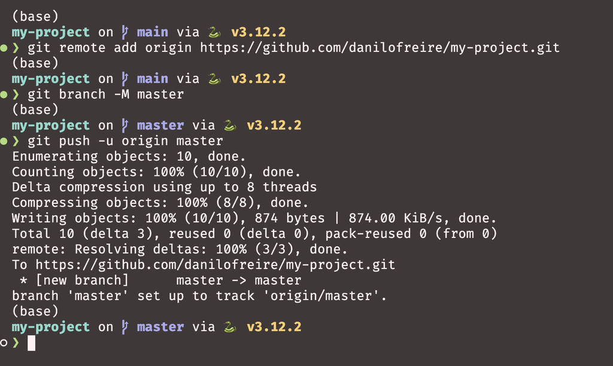

- The `-u` flag sets the upstream. After the first push, plain `git push` is enough
- If your branch is still called `master`, use that name instead. Everything works the same way

# And voi-là! 🎉

## How to pull changes from a remote repository

- To `push` further changes to the remote repository, you just repeat the process:
  - `git add file-name`
  - `git commit -m "Message"`
  - `git push` (no need to add the remote repository again)
- If you work by yourself on your computer only, you already know everything you need to know about Git and you can go home now 😂
- Just kidding! There is still a lot to learn!
- If you work with others, or if you use different computers, you need to know how to `pull` changes from GitHub
- To `pull` changes from a remote repository, use (you’ve guessed it) the command `git pull`
- `git pull` is the equivalent of `git fetch` + `git merge`
  - `git fetch` downloads the changes from the remote repository
  - `git merge` merges the changes with your local repository
- Let’s see an example where I add a commit directly on GitHub
- I will add a [`.gitignore` file to ignore certain files and directories](https://docs.github.com/en/github/using-git/ignoring-files)

## Adding `.gitignore` to our repository

- On GitHub, I click `Add file` > `Create new file`, then commit
- `.gitignore` lists what Git should never track:
  - By name: `secrets.txt`
  - By pattern: `*.csv` for every CSV
  - By folder: `data/`
- Use it for anything large, private, or regenerated: data, API keys, output
- Normally you would create this file in the terminal. I am doing it on GitHub only so we have something to `pull` 😉

[figure not shown]

[figure not shown]

## Pulling changes

- Now, let’s `pull` the changes to my local computer
- Just type `git pull` and the changes will be downloaded and merged
- If you work with others and they push changes to GitHub, you will need to `pull` the changes to your local computer too

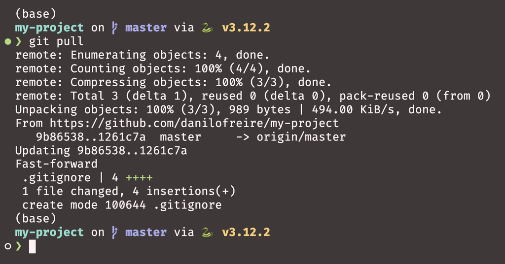

## But wait a minute!

- What if my coauthor and I change the same line?
- Different files, or different lines in the same file: Git merges them for you 👍
- The same line: Git cannot guess which one you want, so it asks you
- This is a merge conflict. It is normal, and it is not a disaster
- You resolve it by opening the file and choosing, or with a tool like `git mergetool`
- Let me change the `.gitignore` file both in my computer and on GitHub, and commit the changes (do not push yet)

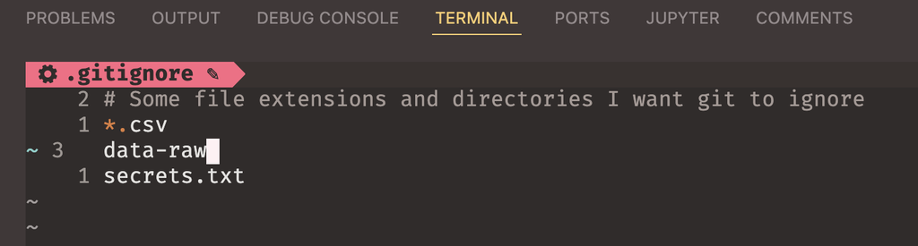

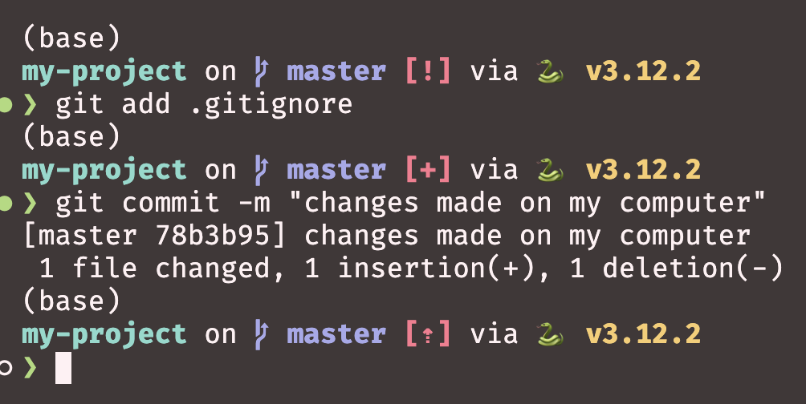

## Changing the same file on GitHub

- I’ve changed the same line of code on GitHub

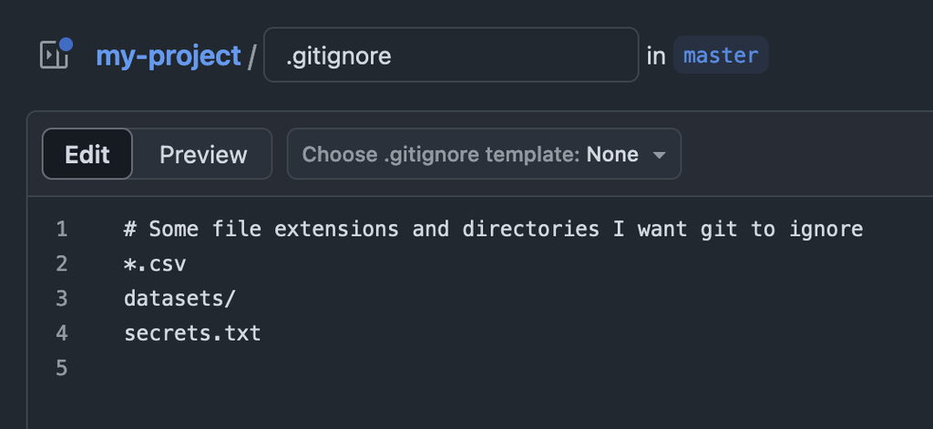

- Let’s see what happens if I try to pull the changes to my local computer
- Oh no!

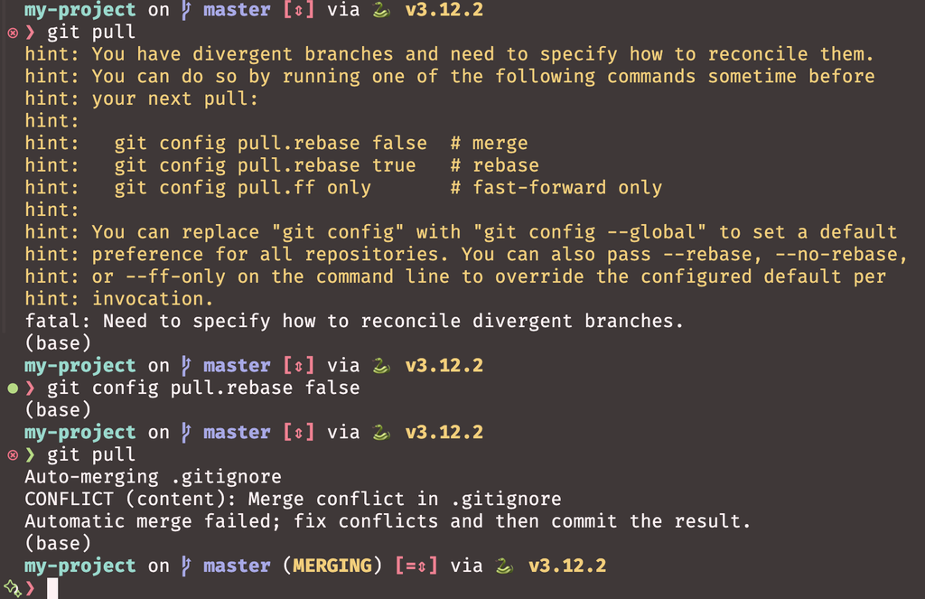

## Resolving conflicts

- To resolve the conflict, you need to open the file in a text editor
- You will see the changes from both you and your coauthor (or yourself)
- You can choose which changes to keep, or you can keep both changes
- After resolving the conflict, you need to `add` the file and `commit` the changes
- Then you can `push` the changes to GitHub

Git marks the conflict with three lines:

- `<<<<<<<` opens your version
- `=======` separates the two versions
- `>>>>>>>` closes their version, and names the commit it came from

Delete the markers along with the text you do not want

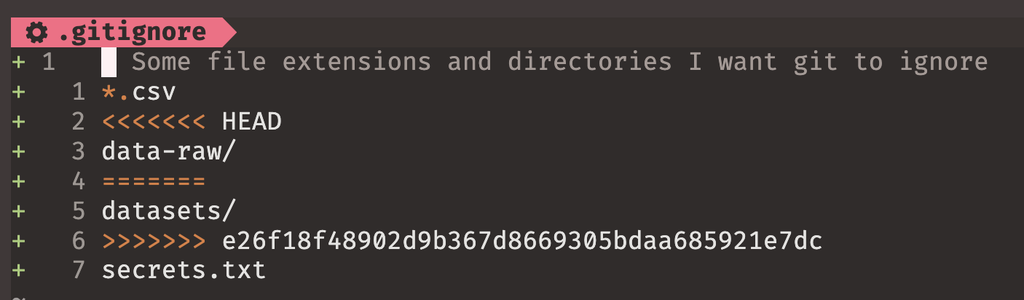

- I will delete some lines and keep the changes from my computer

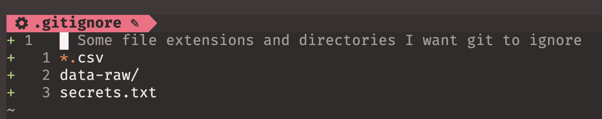

## Resolving conflicts

- Now the conflict is resolved! 🥳

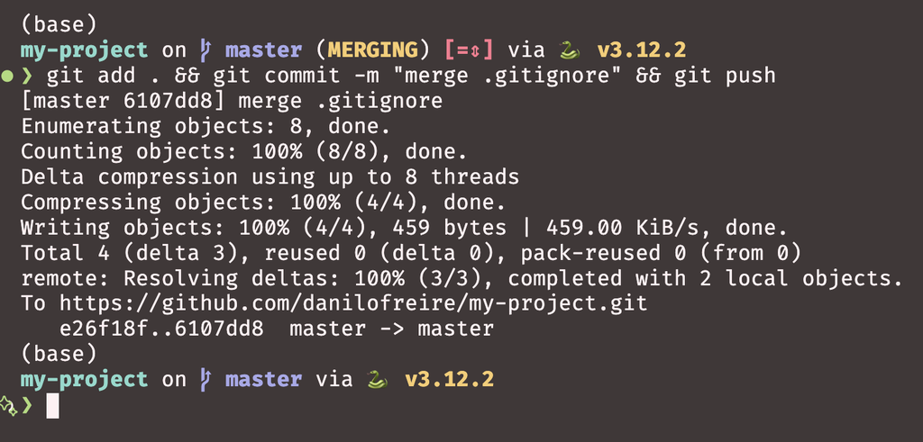

- There are other ways to resolve conflicts, such as using `git mergetool`
- You can also use a graphical tool, such as [Sourcetree](https://www.sourcetreeapp.com) or [GitHub Desktop](https://desktop.github.com)
- But it is good to know how to resolve conflicts manually 😊

[figure not shown]

https://github.com/danilofreire/my-project

# Branches 🌿

## Branches

- Branches are a way to work on different features or versions of your project
- The default branch is called `main` on GitHub, and `master` in older repositories
- However, you can create new branches to work on new features or versions without affecting the `master` branch
- You can create a new branch with the command `git branch branch-name`
- And you can switch to the new branch with the command `git checkout branch-name`
  - Or you can use `git switch branch-name` if you have Git 2.23 or later
- You can also create a new branch and switch to it with the command `git checkout -b branch-name`

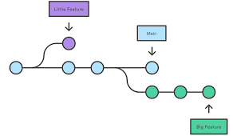

- Branches may or may not be merged back to the `master` branch
- You can also delete branches after merging them

## Branches

- Let’s create a new branch called `feature-1`
  - `git checkout -b feature-1`
- I will add a new file called `feature-1.txt` to the new branch
  - `echo "This is feature 1" > feature-1.txt`
- Then, I will `add`, `commit`, and `push` the changes to GitHub
  - `git add feature-1.txt && git commit -m "Add feature 1"`
  - `git push origin feature-1` (you need to push the new branch to GitHub)

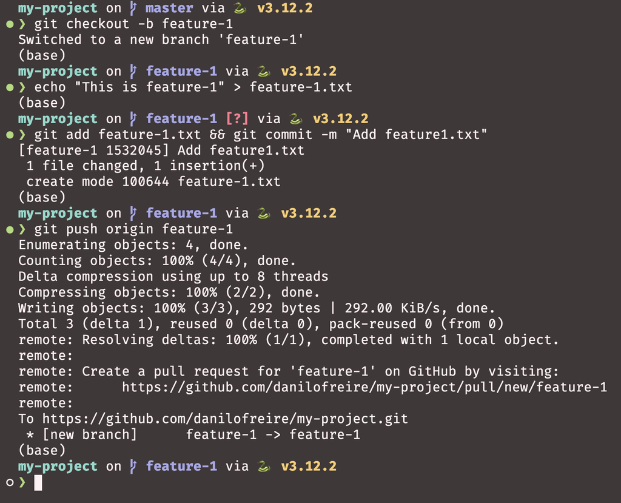

## Branches

- Now the branch is already on GitHub
- Let’s merge the changes to the `master` branch
  - `git checkout master`
  - `git merge feature-1`
  - `git push`
- Done! Let’s see what happened
- You can delete the branch with `git branch -d feature-1`
- To delete the branch on GitHub, use `git push origin --delete feature-1`

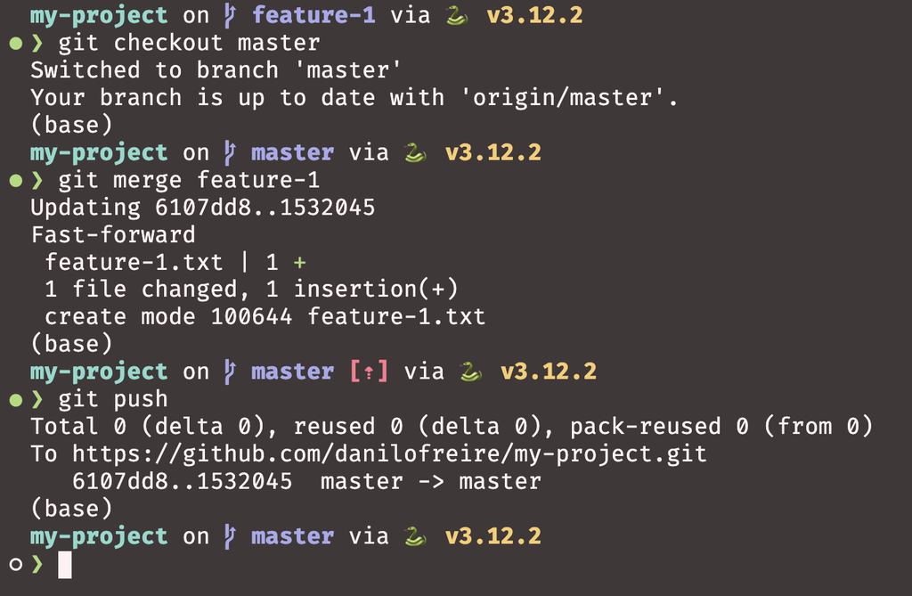

More about branches [here](https://git-scm.com/book/en/v2/Git-Branching-Branches-in-a-Nutshell).

## Going back to a specific commit

- Find the commit first: `git log --oneline` lists the short hashes

Three ways back, from safest to most destructive:

- Look around: `git checkout <hash>`. You are now in detached HEAD, so anything you commit belongs to no branch
- Keep your work: `git switch -c new-branch <hash>` starts a branch at that commit. Usually what you want
- Move the branch itself: `git reset --hard <hash>` rewinds your branch and throws away every commit after it
- `git switch main` brings you back to the present
- Hashes are hexadecimal, so `0-9` and `a-f` only
- `a1b2c3d` is enough. The full form is 40 characters, like `470636f38e409f4f322c48183e19633ebb550625`
- Copy them, do not retype them
- Git keeps almost everything, so a lost commit can usually be recovered with `git reflog`
- On a shared project, branch rather than reset

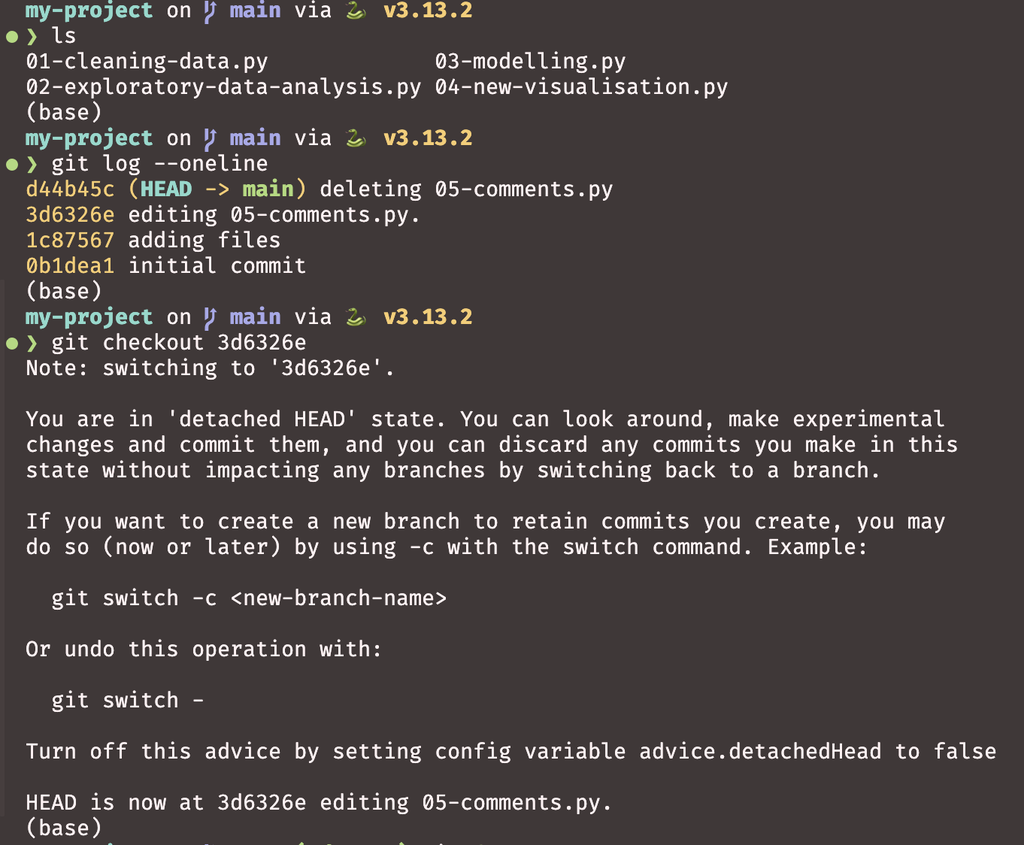

## Going back to a specific commit

- `git switch -c` and `git checkout -b` do the same thing. `switch` is the newer, clearer name (Git 2.23+)
- `git branch -d branch-name` deletes a branch you have finished with
- `-D` forces the deletion, even when the work was never merged
- Rarely needed: replacing `main` altogether. Delete it, rename your current branch to `main`, then push
- Never on a shared repository. Everyone else’s work still points at the branch you deleted

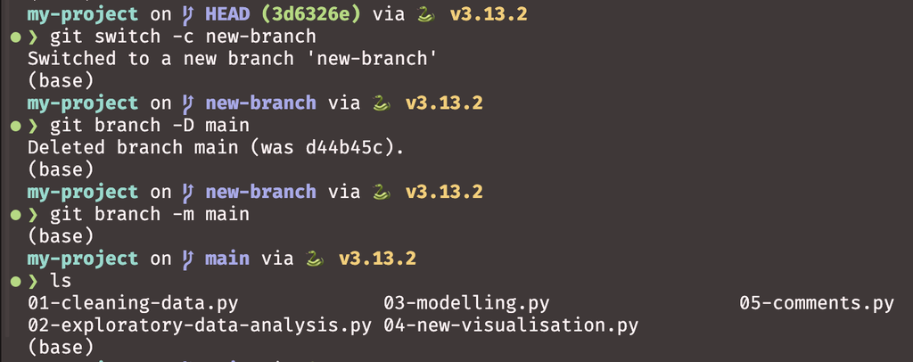

# Fork and clone 🍴

## Cloning

- Cloning downloads a repository from GitHub to your computer
- `git clone https://github.com/username/repository-name.git`
  - For instance, `git clone https://github.com/danilofreire/my-project.git`
- It creates a folder named after the repository
- Your copy stays connected to the original
- So if the repository is not yours, you cannot push to it
- Use it when you already have push rights and want to work locally
- Cloning the `my-project` repository to a different folder

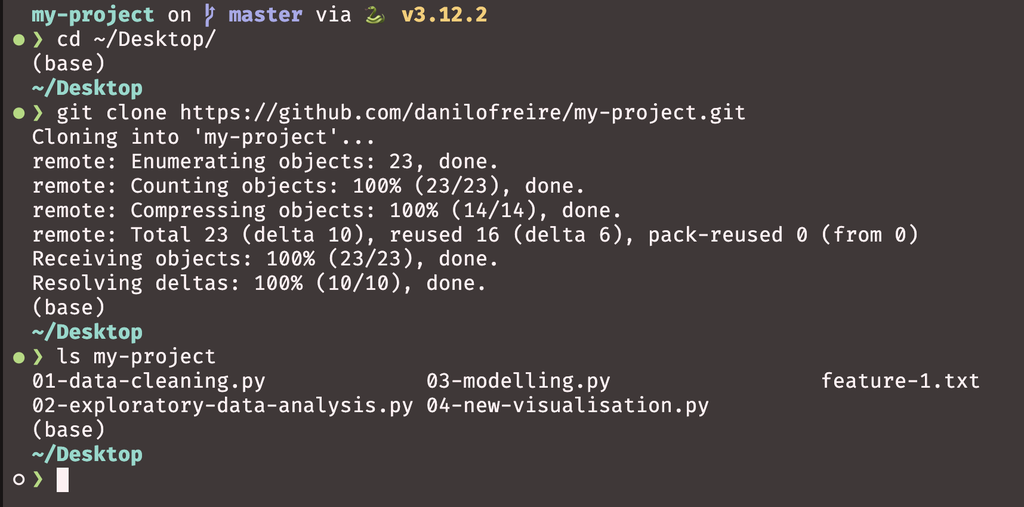

## Forking

- Forking makes your own copy of a repository, on your GitHub account
- Cloning copies to your computer. Forking copies to your account. That is the difference
- Because the fork is yours, you can push to it
- It keeps a link back to the original, called the upstream repository
- You can build something new from it, or open a pull request to suggest changes back

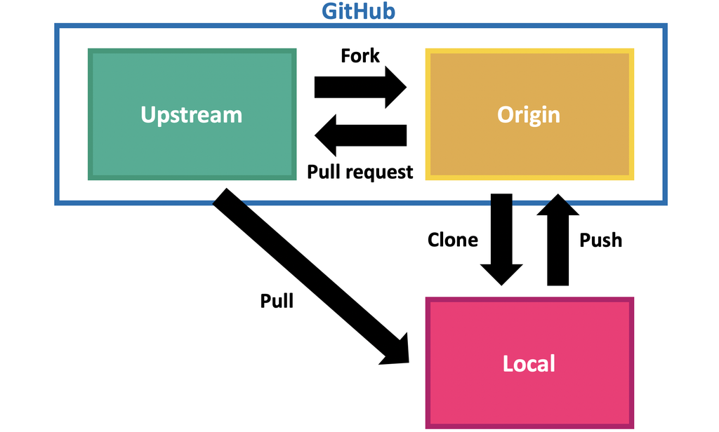

## Forking

- Forking from GitHub is easy, but it requires a few steps
- Forking is not part of Git, but it is part of GitHub
  - That’s why you cannot do it from the command line!
- To fork a repository, go to the repository on GitHub and click on the `Fork` button on the top right corner
- Then, you can clone your forked repository to your computer as you did before

## Forking

[figure not shown]

## Forking

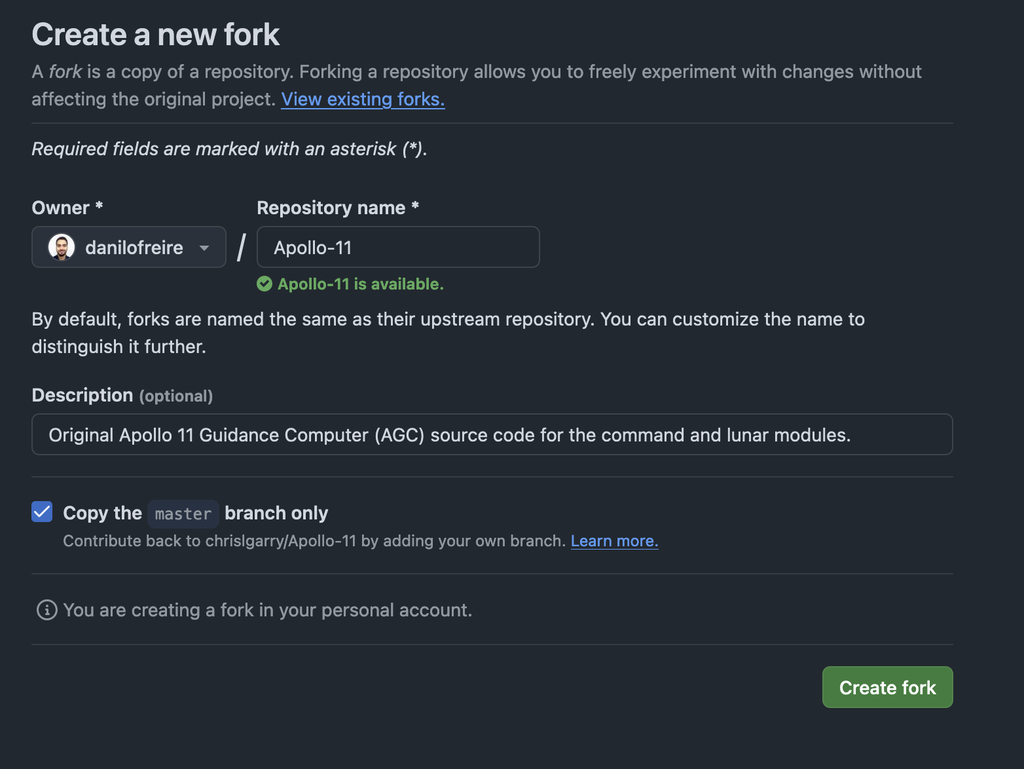

- After forking, you will see the repository on your GitHub account
- Clone it with `git clone https://github.com/your-username/repository-name.git`

## Syncing a forked repository

- A fork does not update itself. The original keeps moving without you
- The easy way: on GitHub, click “Sync fork” and confirm. Commit your own work first
- From the terminal, point at the original once, then pull from it whenever you like:

```bash
git remote add upstream https://github.com/original-user/original-repo.git
git fetch upstream
git merge upstream/main
git push
```

- `origin` is your fork. `upstream` is the repository you forked from

[figure not shown]

- More about syncing a forked repository [here](https://docs.github.com/en/github/collaborating-with-pull-requests/working-with-forks/syncing-a-fork).

# Issues and pull requests 📥

## Issues and pull requests

- Issues are a way to track bugs, enhancements, or other tasks in a repository
- You can create an issue by clicking on the `Issues` tab on GitHub and then on the `New issue` button
- Pull requests are a way to suggest changes after you have forked and changed a repository
- You can create a pull request by clicking on the `Pull requests` tab on GitHub and then on the `New pull request` button
- The repository owner can then review your changes and merge them
- And that’s how open-source projects work! 🤓🎉

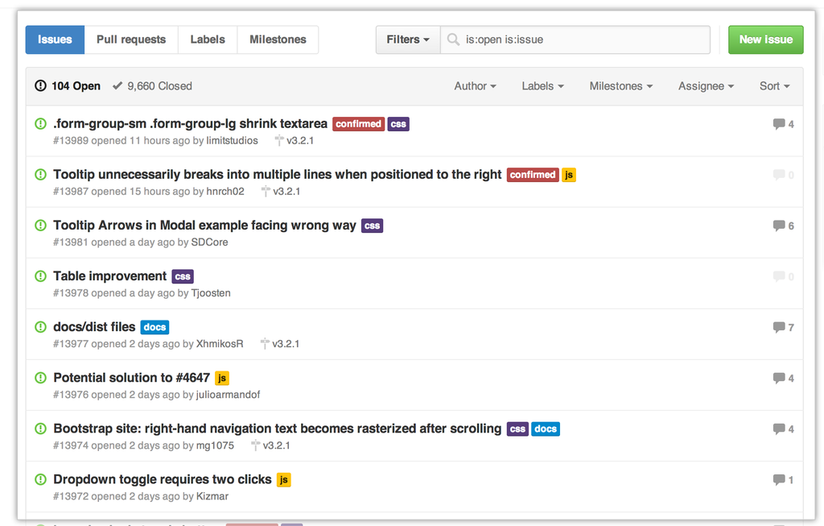

Issues

## Pull requests

[figure not shown]

Pull requests

# Other cool GitHub features 🌟🐙

## GitHub has many other interesting features

### Gists

- [Gists](https://gist.github.com) are a great way to share code snippets, notes, or other text
- You can create a Gist by clicking on the `+` sign on the top right corner of GitHub and then on `New gist`
- Paste any text or code and save it
- You can also create secret Gists that are not indexed by search engines
- Gists also benefit from version control, so you can see the history of changes and revert to previous versions

[figure not shown]

## GitHub Pages

- This is one of the nicest features of GitHub
- [GitHub Pages](https://pages.github.com) allows you to create a website for your project, portfolio, or blog
- As you can see, I use GitHub Pages [for this course](https://danilofreire.github.io/datasci350) and [for my personal website](https://danilofreire.github.io)
- You can create a website by creating a new repository with the name `your-username.github.io`
- Then, you can upload your `.html`, `.css`, and `.js` files to the repository
- Your website will be available at `https://your-username.github.io`
- You can also use custom domains and [Jekyll themes](https://docs.github.com/en/pages/setting-up-a-github-pages-site-with-jekyll), which are pre-designed templates
- Available themes [here](https://pages.github.com/themes)

[figure not shown]

## GitHub Actions

- [GitHub Actions](https://github.com/features/actions) runs code for you, on GitHub’s machines
- You write a `.yml` file listing the steps. GitHub runs them whenever you push
- Typical uses: rebuild a website, run tests, train a model, publish a report
- It can also run on a schedule. Mine [rebuilds a list of my starred repositories every day](https://github.com/danilofreire/awesome-stars)
- The work happens on GitHub’s machines, not yours, and public repositories get a generous free allowance

[figure not shown]

## GitHub Actions

[figure not shown]